# FinalProject

A11962307 Tyler Ly

A12202215 Reginald Wu

A12299775 Karen Ma

A11969225 Ho Tsun Matthew Ho

A12786685 Erika Morozumi

## Question and Hypothesis

Question: How does the existence of public recreation areas correlate with crime rates in the surrounding areas?

Hypothesis: We hypothesize that crime rates are negatively correlated with park scores. In addition, the amount of parks nearby is negatively correlated with crime rates.

# Introduction/Background:

Looking at previous new articles surrounding the subject of parks and criminal activity, we can see there are two stances being taken. On the one hand, people consider the existence of vegetation as a 'screen for criminal activitys. In an article online by the University of Washington, College of Environment--there is less minor crime in places with natural landscapes. Public housing residents with more amounts of plant life have “25% fewer acts of domestic aggression...52% fewer total crimes”[1]. In addition, the existence of vegetation creates a calming atmosphere1.On the flip side, data from NYC parks showed a 23% increase in violent crimes in parks between the year 2015 and 2016. NYPD Police Commissioner Bill Bratton claims that this increase can be attributed to the large number of park visitors[2].One article in the New York Times believes that the data supports the lack of a positive correlation between crimes and parks. This claims that the belief that parks cause crimes is just a result of fear rising from an increase in violent crimes occurring in the daytime at parks[3]. However, the maintenance of parks matters. The American Planning Association writes that “A well-maintained park or open space sends a message that someone cares about it...helps create a perception of safety[4].” This leads us to our hypothesis that the parks’ score, matters more than the existence of the park itself. Not only will the existence of parks be associated with lower levels of crime nearby, a well maintained park with a high park score will be associated with lower levels of crime nearby than a similarly green location with lower park scores.

[1] https://depts.washington.edu/hhwb/Thm_Crime.html [2]http://www.nbcnewyork.com/news/local/Violent-Crime-on-the-Rise-in-NYC-Parks-389500602.html [3] https://www.nytimes.com/2016/08/16/opinion/the-shadow-of-crime-in-city-parks.html?_r=0 [4] https://www.planning.org/cityparks/briefingpapers/saferneighborhoods.htm

```python
import numpy as np
import pandas as pd
import matplotlib.pyplot as plt
import seaborn as sns
from sklearn import datasets
from sklearn.cluster import KMeans
from scipy.cluster.vq import whiten, kmeans2
from scipy.stats import gaussian_kde
sns.set(color_codes=True)

from geopy.distance import vincenty
import patsy
import statsmodels.api as sm
```

# Data Description:

Dataset Name: Park Scores 2005-2014

Link to the dataset: https://data.sfgov.org/Culture-and-Recreation/Park-Scores-2005-2014/fjq8-r8ws

Number of observations: 5495

This dataset contains rows of park name, parkID number, park district it belongs to, year/quarter of evaluation and their respective scores from 0-1. We will use this to try and correlate quality of parks with police incident rates.

Dataset Name: Police Department Incidents

Link to the dataset: https://data.sfgov.org/Public-Safety/Police-Department-Incidents/tmnf-yvry

Number of observations: 2.06M

This dataset contains rows of police incidents, with information ranging from type of incident, date and time, and location (neighborhood as well as latitude and longitude). We will combine this with the other two data sets to try and correlate police incidents with locations of parks.

Dataset Name: Recreation & Park Department Park Info Dataset

Link to the dataset: https://data.sfgov.org/Culture-and-Recreation/Recreation-Park-Department-Park-Info-Dataset/z76i-7s65

Number of observations: 230

This dataset contains rows of all parks with type, location, and size. We will combine this with park scores over the years and police incidents around the area over the years.

```python
#these are functions we have defined to help us extract Locations from our Parks Data
#extracts lat/long from Location 1 column
def findCoords(s):
    if s.find("(") == -1:
        print('help')
        return s
    return s[s.find("(")+1:s.find(")")]

#convert string in Location 1 column into x,y array
#if we wanna use tuple we can do that too
def strToCoord(s):
    coords = list(map(float,s.split(',')))
    #coords = tuple(map(float,test.split(',')))
    return coords
```

# Data Cleaning - Parks.csv:

First we read in our Parks data and then we converted all locations into coordinates. We also dropped all the columns that we were not interested in.

```python
df = pd.read_csv('Parks.csv')
#convert parks location csv file into pandas

df = df.drop(df.columns[[3,4,5,11]], axis=1)
df = df[1:]
df = df[pd.notnull(df['Location 1'])]
df['Location 1'][78] = df['Location 1'][78][13:]
df['Location 1'] = df['Location 1'].apply(findCoords);

df
```

|  | ParkName | ParkType | ParkServiceArea | Zipcode | Acreage | SupDist | ParkID | Location 1 |
| --- | --- | --- | --- | --- | --- | --- | --- | --- |
| 1 | 10TH AVE/CLEMENT MINI PARK | Mini Park | PSA 1 | 94118.0 | 0.66 | 1.0 | 156.0 | 37.78184397, -122.46809908 |
| 2 | 15TH AVENUE STEPS | Mini Park | PSA 4 | 94122.0 | 0.26 | 7.0 | 185.0 | 37.75956493, -122.47226783 |
| 3 | 24TH/YORK MINI PARK | Mini Park | PSA 6 | 94110.0 | 0.12 | 9.0 | 51.0 | 37.75306042, -122.40857543 |
| 4 | 29TH/DIAMOND OPEN SPACE | Neighborhood Park or Playground | PSA 5 | 94131.0 | 0.82 | 8.0 | 194.0 | 37.74360211, -122.43523589 |
| 5 | ADAM ROGERS PARK | Neighborhood Park or Playground | PSA 3 | 94124.0 | 2.74 | 10.0 | 46.0 | 37.73101645, -122.38385466 |
| 6 | ALAMO SQUARE | Neighborhood Park or Playground | PSA 2 | 94117.0 | 12.70 | 5.0 | 117.0 | 37.77634875, -122.43467396 |
| 7 | ALICE CHALMERS PLAYGROUND | Neighborhood Park or Playground | PSA 3 | 94112.0 | 1.68 | 11.0 | 25.0 | 37.7098271, -122.44665065 |
| 8 | ALICE MARBLE TENNIS COURTS | Neighborhood Park or Playground | PSA 1 | 94109.0 | 0.84 | 2.0 | 151.0 | 37.80142776, -122.42034327 |
| 9 | ALIOTO MINI PARK | Mini Park | PSA 6 | 94110.0 | 0.16 | 9.0 | 62.0 | 37.75890196, -122.41821702 |
| 10 | ALLYNE PARK | Neighborhood Park or Playground | PSA 1 | 94123.0 | 0.75 | 2.0 | 131.0 | 37.79746066, -122.42759992 |
| 11 | ALTA PLAZA | Neighborhood Park or Playground | PSA 1 | 94115.0 | 11.91 | 2.0 | 129.0 | 37.79117333, -122.43766978 |
| 12 | ANGELO J. ROSSI PLAYGROUND | Neighborhood Park or Playground | PSA 1 | 94118.0 | 6.47 | 1.0 | 105.0 | 37.77874186, -122.45745402 |
| 13 | APTOS PLAYGROUND | Neighborhood Park or Playground | PSA 4 | 94127.0 | 4.81 | 7.0 | 65.0 | 37.7285246, -122.46654085 |
| 14 | ARGONNE PLAYGROUND | Neighborhood Park or Playground | PSA 1 | 94121.0 | 0.82 | 1.0 | 97.0 | 37.779415, -122.47769976 |
| 16 | Arlington Community Garden | Community Garden | PSA 5 | 94131.0 | 0.13 | 8.0 | 171736.0 | 37.73704325, -122.42637624 |
| 17 | BALBOA NATURAL AREA | Neighborhood Park or Playground | PSA 1 | 94121.0 | 1.84 | 1.0 | 174.0 | 37.77591285, -122.51103949 |
| 18 | BALBOA PARK | Neighborhood Park or Playground | PSA 5 | 94112.0 | 24.02 | 11.0 | 66.0 | 37.72494861, -122.44462659 |
| 20 | BAY VIEW PLAYGROUND | Neighborhood Park or Playground | PSA 3 | 94124.0 | 3.40 | 10.0 | 38.0 | 37.72593906, -122.39329436 |
| 21 | BEIDEMAN/O'FARRELL MINI PARK | Mini Park | PSA 2 | 94115.0 | 0.06 | 5.0 | 106.0 | 37.78238894, -122.43861654 |
| 22 | BERKELEY WAY OPEN SPACE | Neighborhood Park or Playground | PSA 5 | 94131.0 | 0.83 | 8.0 | 2.0 | 37.73956697, -122.43995903 |
| 24 | BERNAL HEIGHTS RECREATION CENTER | Neighborhood Park or Playground | PSA 6 | 94110.0 | 0.74 | 9.0 | 33.0 | 37.73844636, -122.41615685 |
| 25 | BILLY GOAT HILL | Neighborhood Park or Playground | PSA 5 | 94131.0 | 3.67 | 8.0 | 5.0 | 37.74140787, -122.43319872 |
| 26 | BROADWAY TUNNEL EAST MINI PARK | Mini Park | PSA 1 | 94133.0 | 0.03 | 3.0 | 204.0 | 37.79699682, -122.412901 |
| 27 | BROADWAY TUNNEL WEST MINI PARK | Mini Park | PSA 1 | 94109.0 | 0.12 | 3.0 | 203.0 | 37.79643576, -122.41742319 |
| 28 | BROOKS PARK | Neighborhood Park or Playground | PSA 4 | 94132.0 | 3.77 | 11.0 | 18.0 | 37.71727397, -122.46676875 |
| 29 | BROTHERHOOD/CHESTER MINI PARK | Mini Park | PSA 4 | 94132.0 | 0.59 | 7.0 | 160.0 | 37.71238249, -122.46990318 |
| 30 | BUCHANAN STREET MALL | Neighborhood Park or Playground | PSA 2 | 94102.0 | 1.81 | 5.0 | 121.0 | 37.77949531, -122.42856481 |
| 31 | BUENA VISTA PARK | Regional Park | PSA 5 | 94117.0 | 36.08 | 8.0 | 81.0 | 37.7685639, -122.44137945 |
| 32 | BUSH/BRODERICK MINI PARK | Mini Park | PSA 2 | 94115.0 | 0.18 | 5.0 | 108.0 | 37.78557814, -122.44253511 |
| 33 | CABRILLO PLAYGROUND | Neighborhood Park or Playground | PSA 1 | 94121.0 | 0.89 | 1.0 | 95.0 | 37.77286672, -122.49870214 |
| ... | ... | ... | ... | ... | ... | ... | ... | ... |
| 195 | SILVER TERRACE PLAYGROUND | Neighborhood Park or Playground | PSA 3 | 94124.0 | 5.47 | 10.0 | 39.0 | 37.73285911, -122.40314958 |
| 196 | SOUTH END ROWING/DOLPHIN CLUB | Concession | PSA 1 | 94109.0 | 1.11 | 3.0 | 190.0 | 37.80796044, -122.42126376 |
| 197 | SOUTH PARK | Neighborhood Park or Playground | PSA 2 | 94107.0 | 1.12 | 6.0 | 56.0 | 37.78157949, -122.39395227 |
| 198 | SOUTH SUNSET PLAYGROUND | Neighborhood Park or Playground | PSA 4 | 94116.0 | 3.72 | 4.0 | 85.0 | 37.73738679, -122.49845174 |
| 199 | ST MARY'S REC CENTER | Neighborhood Park or Playground | PSA 6 | 94110.0 | 13.60 | 9.0 | 31.0 | 37.73365828, -122.42064294 |
| 200 | ST MARY'S SQUARE | Civic Plaza or Square | PSA 1 | 94108.0 | 1.11 | 3.0 | 136.0 | 37.79205617, -122.40511712 |
| 201 | STATES STREET PLAYGROUND | Neighborhood Park or Playground | PSA 5 | 94114.0 | 2.76 | 8.0 | 200.0 | 37.76380044, -122.43785312 |
| 202 | SUE BIERMAN PARK | Neighborhood Park or Playground | PSA 1 | 94111.0 | 4.41 | 3.0 | 143.0 | 37.79592597, -122.3965106 |
| 203 | SUNNYSIDE CONSERVATORY | Mini Park | PSA 5 | 94131.0 | 0.26 | 8.0 | 180.0 | 37.73193576, -122.44076127 |
| 204 | SUNNYSIDE PLAYGROUND | Neighborhood Park or Playground | PSA 5 | 94127.0 | 2.37 | 7.0 | 67.0 | 37.73366412, -122.4474787 |
| 205 | SUNSET PLAYGROUND | Neighborhood Park or Playground | PSA 4 | 94122.0 | 3.29 | 4.0 | 93.0 | 37.75658875, -122.48684698 |
| 206 | TANK HILL | Neighborhood Park or Playground | PSA 5 | 94117.0 | 2.87 | 5.0 | 76.0 | 37.75994801, -122.44768643 |
| 208 | TENDERLOIN CHILDREN'S REC CENTER | Neighborhood Park or Playground | PSA 2 | 94109.0 | 0.61 | 6.0 | 168.0 | 37.78482103, -122.41540228 |
| 210 | TURK/HYDE MINI PARK | Mini Park | PSA 2 | 94102.0 | 0.11 | 6.0 | 192.0 | 37.78274031, -122.41596297 |
| 212 | UNION SQUARE | Civic Plaza or Square | PSA 2 | 94108.0 | 2.60 | 3.0 | 135.0 | 37.78793122, -122.40750049 |
| 213 | UPPER NOE RECREATION CENTER | Neighborhood Park or Playground | PSA 5 | 94131.0 | 2.51 | 8.0 | 22.0 | 37.74243091, -122.42779751 |
| 214 | UTAH/18TH MINI PARK | Mini Park | PSA 2 | 94110.0 | 0.10 | 10.0 | 202.0 | 37.76251745, -122.40599759 |
| 215 | VICTORIA MANALO DRAVES PARK | Neighborhood Park or Playground | PSA 2 | 94103.0 | 2.52 | 6.0 | 169.0 | 37.77700947, -122.40595532 |
| 216 | VISITACION VALLEY GREENWAY | Neighborhood Park or Playground | PSA 3 | 94134.0 | 2.13 | 10.0 | 177.0 | 37.71476638, -122.40613194 |
| 217 | VISITACION VALLEY PLAYGROUND | Neighborhood Park or Playground | PSA 3 | 94134.0 | 2.05 | 10.0 | 27.0 | 37.71240126, -122.40908547 |
| 218 | WALTER HAAS PLAYGROUND | Neighborhood Park or Playground | PSA 5 | 94131.0 | 4.40 | 8.0 | 4.0 | 37.74058384, -122.43436978 |
| 219 | WASHINGTON SQUARE | Civic Plaza or Square | PSA 1 | 94133.0 | 2.26 | 3.0 | 147.0 | 37.80083781, -122.41002829 |
| 220 | WASHINGTON/HYDE MINI PARK | Mini Park | PSA 1 | 94109.0 | 0.15 | 3.0 | 144.0 | 37.79400955, -122.41740007 |
| 221 | WEST PORTAL PLAYGROUND | Neighborhood Park or Playground | PSA 4 | 94127.0 | 1.91 | 7.0 | 68.0 | 37.74160392, -122.46524393 |
| 222 | WEST SUNSET PLAYGROUND | Neighborhood Park or Playground | PSA 4 | 94116.0 | 17.16 | 4.0 | 91.0 | 37.74899627, -122.49800859 |
| 223 | White Crane Springs Community Garden | Community Garden | PSA 4 | 94131.0 | 2.68 | 7.0 | 123631.0 | 37.75758279, -122.4633024 |
| 225 | WOH HEI YUEN PARK | Neighborhood Park or Playground | PSA 1 | 94133.0 | 0.31 | 3.0 | 170.0 | 37.79584858, -122.41033649 |
| 226 | Wolfe Lane Community Garden | Community Garden | PSA 6 | 94110.0 | 0.05 | 9.0 | 171608.0 | 37.74528401, -122.4066037 |
| 228 | YOUNGBLOOD COLEMAN PLAYGROUND | Neighborhood Park or Playground | PSA 3 | 94124.0 | 6.13 | 10.0 | 45.0 | 37.73876792, -122.38450221 |
| 229 | GUY PLACE MINI PARK | Mini Park | PSA 2 | 94105.0 | 0.00 | 6.0 | 445358.0 | 37.7750329000483, -122.41916720030605 |

202 rows × 8 columns

```python
#make coordinates for plotting
coords = []
for row in df.itertuples():
    coords.append(strToCoord(row._8))
coords = np.asarray(coords)
```

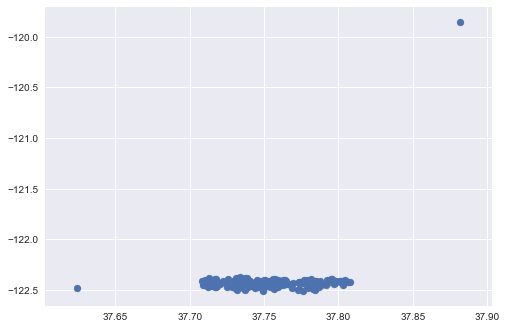

```python
#scatter matrix with previous coordinates
plt.scatter(coords.T[0],coords.T[1])
plt.show()
```

After doing an initial plotting of all the parks on a scatter matrix we noticed some outlier parks. We decided to take out the outliers and replot the parks.

```python
#Take out outliers
idx = 0
new_coords = []
for i,j in coords:
    if i < 37.65 or j > -120:
        print(idx,i,j)
    else:
        new_coords.append([i,j])
    idx += 1
new_coords = np.asarray(new_coords)
print(len(new_coords))
```

```
30 37.88160218 -119.85076005
170 37.62439438 -122.48189132
200
```

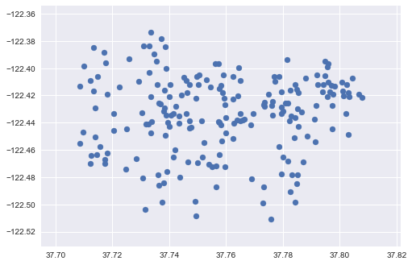

```python
#scatter matrix without the outliers
plt.scatter(new_coords.T[0],new_coords.T[1])
plt.show()
```

Now we needed to find the year of each park score since the given format is FY05Q3 and what we're interested in is 05. In addition, we only care about the years that overlap through our three datasets which are 2012-2014

```python
#create method that finds year of each data
#to narrow down the timespan of data to match other data to find accurate correlation
def getYear(s):
    if s.find("Y") == -1 or s.find("Q") == -1:
        print('help')
        return s
    return s[s.find("Y")+1:s.find("Q")]
```

# Data Cleaning - Scores.csv:

Now that we had our parks cleaned up and ready for use, we read in our scores file and dropped all the years that we were not interested in. Then we separated each year into its own dataframe. This way, we could find the average park score for each park. This way, instead of having a score for all 4 quarters of a year. We would have one for each year. Then, we could combine our park and score datasets together so each park would have a location and scores associated with it.

```python
df2 = pd.read_csv('Scores.csv')
#convert park scores csv file into pandas

df2 = df2.dropna()
df_all = pd.read_csv('Scores.csv')
df2['FQ'] = df2['FQ'].apply(getYear)
#take years 2012-2014
df2 = df2[(df2['FQ'] == '12') | (df2['FQ'] == '13') | (df2['FQ'] == '14')]
```

```python
#separate each data into their own years
df12 = df2[df2['FQ'] == '12']
df13 = df2[df2['FQ'] == '13']
df14 = df2[df2['FQ'] == '14']
```

```python
means_12 = dict()
for key in np.unique(np.array(df12['ParkID'])):
    means_12[key] = np.mean(np.array(df12[df12['ParkID'] == key]['Score']))
means_13 = dict()
for key in np.unique(np.array(df13['ParkID'])):
    means_13[key] = np.mean(np.array(df13[df13['ParkID'] == key]['Score']))
means_14 = dict()
for key in np.unique(np.array(df14['ParkID'])):
    means_14[key] = np.mean(np.array(df14[df14['ParkID'] == key]['Score']))
```

```python
rows_list = []
for row in np.unique(df2['ParkID']):
    #print(row in df2['ParkID'], row in df['ParkID'])
    if row in list(df['ParkID']):
        dict1 = {}
        dict1['Park'] = list(df2[df2['ParkID'] == row]['Park'])[0]
        dict1['ParkID'] = row
        #print(row)
        dict1['Location'] = list(df[df['ParkID'] == int(row)]['Location 1'])[0]
        if row in means_12:
            dict1['mean_score_12'] = means_12[row]
        if row in means_13:
            dict1['mean_score_13'] = means_13[row]
        if row in means_14:
            dict1['mean_score_14'] = means_14[row]
        rows_list.append(dict1)
df_parks = pd.DataFrame(rows_list)
```

```python
#check out end result
df_parks
```

|  | Location | Park | ParkID | mean_score_12 | mean_score_13 | mean_score_14 |
| --- | --- | --- | --- | --- | --- | --- |
| 0 | 37.7400257, -122.44273225 | Glen Park | 1 | 0.891000 | 0.925250 | 0.913000 |
| 1 | 37.74058384, -122.43436978 | Walter Haas Playground | 4 | 0.929500 | 0.880500 | 0.932500 |
| 2 | 37.74347014, -122.44055037 | George Christopher Playground | 7 | 0.946000 | 0.936750 | 0.953750 |
| 3 | 37.74727823, -122.43893283 | Douglass Playground | 8 | 0.945750 | 0.824500 | 0.869500 |
| 4 | 37.73060291, -122.48041933 | Rolph Nicol Playground | 9 | 0.924750 | 0.924000 | 0.872000 |
| 5 | 37.72482337, -122.47385187 | Junipero Serra Playground | 13 | 0.940500 | 0.898333 | 0.964000 |
| 6 | 37.70860406, -122.4553029 | Lessing-Sears Mini Park | 14 | 0.855250 | 0.911000 | 0.784500 |
| 7 | 37.71388814, -122.45029719 | Cayuga Playground | 15 | NaN | NaN | 0.981250 |
| 8 | 37.71451213, -122.46369333 | Randolph-Bright Mini Park | 16 | 0.823333 | 0.939750 | 0.894500 |
| 9 | 37.71750931, -122.47028126 | Merced Heights Playground | 17 | 0.859500 | 0.956000 | 0.922500 |
| 10 | 37.71727397, -122.46676875 | Brooks Park | 18 | 0.908250 | 0.823750 | 0.918750 |
| 11 | 37.71577016, -122.45757024 | Minnie & Lovie Ward Recreation Center | 19 | 0.832500 | 0.876250 | 0.876000 |
| 12 | 37.74243091, -122.42779751 | Upper Noe Recreation Center | 22 | 0.913333 | 0.963750 | 0.935000 |
| 13 | 37.74950391, -122.42199245 | Juri Commons | 23 | 0.970000 | 0.924250 | 0.907750 |
| 14 | 37.75020058, -122.4122356 | Garfield Square | 24 | 0.871250 | 0.964250 | 0.965250 |
| 15 | 37.7098271, -122.44665065 | Alice Chalmers Playground | 25 | 0.903250 | 0.815250 | 0.815250 |
| 16 | 37.70854271, -122.41314877 | Kelloch Velasco Mini Park | 26 | 0.952750 | 0.916250 | 0.913000 |
| 17 | 37.71240126, -122.40908547 | Visitacion Valley Playground | 27 | 0.865800 | 0.899250 | 0.717500 |
| 18 | 37.7180842, -122.41907209 | John McLaren Park | 28 | 0.787875 | 0.819909 | 0.899438 |
| 19 | 37.7203554, -122.43321862 | Excelsior Playground | 29 | 0.938500 | 0.843667 | 0.869750 |
| 20 | 37.72934205, -122.40978 | Palega Recreation Center | 30 | 0.845667 | NaN | 0.969500 |
| 21 | 37.73365828, -122.42064294 | St. Mary's Recreation Center | 31 | 0.944333 | 0.977500 | 0.970250 |
| 22 | 37.73844636, -122.41615685 | Bernal Heights Recreation Center | 33 | 0.985750 | 0.939750 | 0.965500 |
| 23 | 37.74442266, -122.41966647 | Coleridge Mini Park | 34 | 0.938250 | 1.000000 | 0.962500 |
| 24 | 37.74706232, -122.41202466 | Precita Park | 37 | 0.927500 | 0.973750 | 0.944750 |
| 25 | 37.72593906, -122.39329436 | Bay View Playground | 38 | 0.882250 | 0.892250 | 0.836750 |
| 26 | 37.73285911, -122.40314958 | Silver Terrace Playground | 39 | 0.924250 | 0.911500 | 0.877500 |
| 27 | 37.73453491, -122.389412 | Joseph Lee Recreation Center | 40 | 0.938250 | 0.905000 | 0.941500 |
| 28 | 37.70996909, -122.39820878 | Little Hollywood Park | 42 | 0.864000 | 0.902000 | 0.833000 |
| 29 | 37.71698202, -122.38809021 | Gilman Playground | 44 | 0.924000 | 0.782250 | 0.796500 |
| ... | ... | ... | ... | ... | ... | ... |
| 125 | 37.73273279, -122.4408417 | Joost-Baden Mini Park | 158 | 0.961000 | 1.000000 | 0.937500 |
| 126 | 37.73033758, -122.43294264 | Cayuga-Lamartine Mini Park | 159 | 0.893250 | 0.946000 | 0.852600 |
| 127 | 37.74928062, -122.50817528 | Lower Great Highway | 163 | 0.780000 | 0.814750 | 0.856750 |
| 128 | 37.7140459, -122.42923866 | Crocker Amazon Playground | 164 | 0.931000 | 0.904000 | 0.861625 |
| 129 | 37.79131306, -122.45397275 | Julius Kahn Playground | 166 | 0.937250 | 0.929500 | 0.951750 |
| 130 | 37.75223367, -122.45453246 | Midtown Terrace Playground | 167 | 0.964250 | 0.961750 | 0.975000 |
| 131 | 37.78482103, -122.41540228 | Tenderloin Children's Recreation Center | 168 | 0.939000 | 0.978000 | 0.966500 |
| 132 | 37.77700947, -122.40595532 | Victoria Manalo Draves Park | 169 | 0.943500 | 0.959750 | 0.970500 |
| 133 | 37.79584858, -122.41033649 | Woh Hei Yuen Park | 170 | 0.956250 | 0.916000 | 0.895500 |
| 134 | 37.78326998, -122.47797676 | Richmond Recreation Center | 172 | 0.954750 | 0.991750 | 0.992500 |
| 135 | 37.74607638, -122.40880708 | Mullen-Peralta Mini Park | 176 | 0.936000 | 0.968750 | 0.972250 |
| 136 | 37.71476638, -122.40613194 | Visitacion Valley Greenway | 177 | 0.971750 | 0.920750 | 0.920000 |
| 137 | 37.73193576, -122.44076127 | Sunnyside Conservatory | 180 | 0.987250 | 0.992750 | 0.978000 |
| 138 | 37.78018588, -122.43178038 | Fillmore-Turk Mini Park | 182 | 0.818000 | 0.877667 | 0.921000 |
| 139 | 37.80289031, -122.4178443 | Fay Park | 184 | 0.993000 | 0.978500 | 0.972000 |
| 140 | 37.75439053, -122.41356906 | Parque Ninos Unidos | 187 | 0.888250 | 0.935250 | 0.964000 |
| 141 | 37.73551382, -122.39472336 | Palou-Phelps Park | 188 | 0.843500 | 0.805500 | 0.886750 |
| 142 | 37.76415431, -122.42027989 | Kid Power Park | 191 | 0.983750 | 0.989000 | 0.989000 |
| 143 | 37.78274031, -122.41596297 | Turk-Hyde Mini Park | 192 | 0.826500 | 0.960750 | 0.922000 |
| 144 | 37.76578838, -122.43790519 | Peixotto Playground | 195 | 0.980500 | 0.923250 | 0.929500 |
| 145 | 37.71262222, -122.46422924 | Head-Brotherhood Mini Park | 196 | 0.871000 | 0.975250 | 0.836250 |
| 146 | 37.74624354, -122.41812033 | Coso-Precita Mini Park | 199 | 0.937500 | 1.000000 | 0.984500 |
| 147 | 37.76380044, -122.43785312 | States Street Playground | 200 | 0.878250 | 0.851000 | 0.829750 |
| 148 | 37.74021712, -122.41187368 | Prentiss Mini Park | 201 | 0.943750 | 0.950333 | 0.984500 |
| 149 | 37.76251745, -122.40599759 | Utah-18th Street Mini Park | 202 | 0.869750 | 1.000000 | 0.954750 |
| 150 | 37.79643576, -122.41742319 | Broadway Tunnel West Mini Park | 203 | 0.935250 | 0.910750 | 0.935750 |
| 151 | 37.77622289, -122.42441307 | Patricia's Green in Hayes Valley | 59481 | 0.888000 | 0.983000 | 0.863000 |
| 152 | 37.76655956, -122.43732268 | Roosevelt-Henry Steps | 107857 | 0.881500 | 0.900000 | 0.913000 |
| 153 | 37.72245982, -122.41392441 | Louis Sutter Playground | 137665 | 0.868667 | 0.929750 | 0.906000 |
| 154 | 37.71348444, -122.41659732 | Herz Playground | 137671 | 0.848000 | 0.876500 | 0.909333 |

155 rows × 6 columns

## Data Visualization - Parks/Scores.csv:

Now we have finished data cleaning/pre processing our park and score data. We've also played around with initial data visualization using basic scatter matrix and hexbin plotting.

```python
coords = []
for row in df_parks.itertuples():
    coords.append(strToCoord(row.Location))
coords = np.asarray(coords)
len(coords)
```

```
155
```

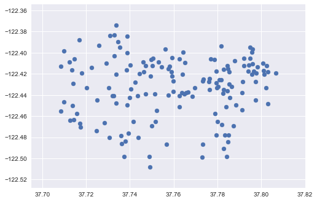

```python
plt.scatter(coords.T[0],coords.T[1])
plt.show()
```

We already visualized the spread of the parks as a scatter matrix but we decided to use hexbins instead to create a grouping of the parks overall.

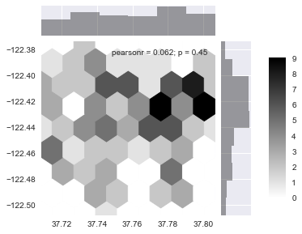

```python
hex_park = sns.jointplot(x=coords.T[0], y=coords.T[1], kind="hex", color="k");

sns.plt.subplots_adjust(left=0.2, right=0.8, top=0.8, bottom=0.2)  # shrink fig so cbar is visible
cax = hex_park.fig.add_axes([.85, .25, .05, .4])  # x, y, width, height
sns.plt.colorbar(cax=cax)
plt.show()
```

## Data Cleaning - Crime Dataset:

First we read in our csv file and then dropped any rows with NaN values. Then we dropped all the columns of data we didn't need. Finally, we took only th year we were interested in, from 2012-2014. This gave us a final dataset of 443783 rows.

```python
def getCYear(s):
    year = s[8:10]
    #print(year)
    return year
```

```python
####READING INTO CRIME DATA
crime_df = pd.read_csv('Police_Department_Incidents.csv')
crime_df = crime_df.dropna()
crime_df = crime_df.drop(['IncidntNum', 'Descript','DayOfWeek','Time','Resolution','Address','PdId'], axis=1)
#print(list(crime_df.columns.values))
crime_df["Date"] = crime_df["Date"].apply(getCYear)
crime_df = crime_df[(crime_df['Date']=="12") | (crime_df['Date']=="13") | (crime_df['Date']=="14")]
crime_df['Location'] = crime_df['Location'].apply(lambda s:s[1:len(s)-1])
```

```python
crime_df
```

|  | Category | Date | X | Y | Location |
| --- | --- | --- | --- | --- | --- |
| 30 | ARSON | 14 | -122.420875 | 37.791494 | (37.7914943051906, -122.420874632415) |
| 132 | FRAUD | 14 | -122.400749 | 37.791178 | (37.7911776792224, -122.400748631911) |
| 280 | VEHICLE THEFT | 14 | -122.461139 | 37.709085 | (37.7090849156407, -122.461139183524) |
| 305 | ASSAULT | 14 | -122.403434 | 37.787643 | (37.78764305018, -122.403434086745) |
| 324 | ROBBERY | 14 | -122.417105 | 37.774324 | (37.7743242867908, -122.417104895556) |
| 380 | ASSAULT | 14 | -122.403595 | 37.727634 | (37.7276340992506, -122.403595293514) |
| 515 | ASSAULT | 14 | -122.421971 | 37.742375 | (37.7423752245255, -122.421970919029) |
| 533 | NON-CRIMINAL | 14 | -122.446286 | 37.774871 | (37.7748707258015, -122.446285631005) |
| 598 | LARCENY/THEFT | 14 | -122.432915 | 37.784353 | (37.7843533426568, -122.432914603494) |
| 599 | NON-CRIMINAL | 14 | -122.394103 | 37.776383 | (37.7763827130285, -122.394102624525) |
| 600 | NON-CRIMINAL | 14 | -122.401378 | 37.789264 | (37.7892639310458, -122.401378067544) |
| 611 | LARCENY/THEFT | 14 | -122.417210 | 37.790046 | (37.7900459017168, -122.41720963943) |
| 612 | NON-CRIMINAL | 14 | -122.409313 | 37.784348 | (37.7843478513151, -122.409313111431) |
| 712 | NON-CRIMINAL | 14 | -122.404799 | 37.794453 | (37.7944525389481, -122.404799424951) |
| 719 | NON-CRIMINAL | 14 | -122.422199 | 37.806435 | (37.8064351103515, -122.42219944483) |
| 739 | NON-CRIMINAL | 14 | -122.466181 | 37.762174 | (37.7621738188702, -122.466180771685) |
| 747 | LARCENY/THEFT | 14 | -122.406554 | 37.765843 | (37.7658426354415, -122.406553700757) |
| 760 | NON-CRIMINAL | 14 | -122.419983 | 37.768273 | (37.7682726763619, -122.419983447697) |
| 802 | LARCENY/THEFT | 14 | -122.406482 | 37.782732 | (37.7827317884887, -122.406481972743) |
| 960 | NON-CRIMINAL | 14 | -122.489805 | 37.770892 | (37.7708917848848, -122.489804747862) |
| 976 | ASSAULT | 14 | -122.419672 | 37.765050 | (37.7650501214668, -122.419671780296) |
| 1046 | NON-CRIMINAL | 14 | -122.445537 | 37.771142 | (37.7711417554207, -122.44553734204) |
| 1085 | NON-CRIMINAL | 14 | -122.464812 | 37.773489 | (37.773489338522, -122.464812286077) |
| 1165 | ASSAULT | 14 | -122.401378 | 37.789264 | (37.7892639310458, -122.401378067544) |
| 1250 | NON-CRIMINAL | 14 | -122.402070 | 37.788720 | (37.7887198688133, -122.402070243227) |
| 1270 | VEHICLE THEFT | 14 | -122.416262 | 37.785375 | (37.7853750846376, -122.416261836834) |
| 1286 | LARCENY/THEFT | 14 | -122.401494 | 37.785828 | (37.7858284327692, -122.401494315269) |
| 1355 | NON-CRIMINAL | 14 | -122.410691 | 37.807891 | (37.8078911906226, -122.410690675854) |
| 1498 | VEHICLE THEFT | 14 | -122.416642 | 37.787245 | (37.787245037815, -122.416642370005) |
| 1542 | ASSAULT | 14 | -122.416294 | 37.777494 | (37.777493677735, -122.416293820935) |
| ... | ... | ... | ... | ... | ... |
| 1798624 | LARCENY/THEFT | 13 | -122.447055 | 37.759735 | (37.7597348090272, -122.447055013255) |
| 1798633 | DRUG/NARCOTIC | 13 | -122.408518 | 37.773760 | (37.773760403167, -122.408518394535) |
| 1798640 | OTHER OFFENSES | 12 | -122.452638 | 37.737491 | (37.7374907438525, -122.452638103443) |
| 1798641 | NON-CRIMINAL | 14 | -122.438555 | 37.799644 | (37.7996439186587, -122.438555301368) |
| 1798642 | NON-CRIMINAL | 14 | -122.435563 | 37.760801 | (37.760801062884, -122.435563016294) |
| 1798643 | WARRANTS | 14 | -122.396535 | 37.710660 | (37.7106603302503, -122.396535107224) |
| 1798644 | ASSAULT | 14 | -122.416343 | 37.782447 | (37.7824465135592, -122.416342977622) |
| 1798645 | OTHER OFFENSES | 14 | -122.419673 | 37.789669 | (37.789668941238, -122.419672954945) |
| 1798646 | OTHER OFFENSES | 14 | -122.393357 | 37.730076 | (37.730076338153, -122.393356904201) |
| 1798647 | OTHER OFFENSES | 14 | -122.494240 | 37.778672 | (37.7786722890662, -122.494239651236) |
| 1798648 | ASSAULT | 14 | -122.426992 | 37.708258 | (37.7082584667664, -122.426992394342) |
| 1798649 | NON-CRIMINAL | 14 | -122.429645 | 37.772264 | (37.7722642986091, -122.429644614552) |
| 1798650 | WARRANTS | 14 | -122.397736 | 37.759883 | (37.7598828513609, -122.397736262234) |
| 1798651 | NON-CRIMINAL | 14 | -122.406605 | 37.757158 | (37.7571580431915, -122.406604919508) |
| 1798652 | WARRANTS | 14 | -122.403405 | 37.775421 | (37.775420706711, -122.403404791479) |
| 1798653 | OTHER OFFENSES | 14 | -122.425565 | 37.781270 | (37.7812701611726, -122.425564924002) |
| 1798654 | NON-CRIMINAL | 14 | -122.410135 | 37.784189 | (37.7841889075267, -122.410135236377) |
| 1798655 | EMBEZZLEMENT | 14 | -122.395986 | 37.778835 | (37.7788348205682, -122.395985970867) |
| 1798656 | NON-CRIMINAL | 14 | -122.464045 | 37.761316 | (37.7613161836641, -122.464044777804) |
| 1798657 | FRAUD | 14 | -122.406539 | 37.756486 | (37.7564864109309, -122.406539115148) |
| 1798658 | OTHER OFFENSES | 14 | -122.417720 | 37.710661 | (37.7106612347749, -122.417720424652) |
| 1798659 | NON-CRIMINAL | 14 | -122.481183 | 37.743727 | (37.7437268170337, -122.48118317163) |
| 1798660 | OTHER OFFENSES | 14 | -122.416569 | 37.773203 | (37.773202918455, -122.416569284944) |
| 1798661 | NON-CRIMINAL | 14 | -122.480725 | 37.783123 | (37.7831234195168, -122.48072545461) |
| 1798662 | NON-CRIMINAL | 14 | -122.408311 | 37.720351 | (37.7203514651097, -122.408310780232) |
| 1798663 | OTHER OFFENSES | 14 | -122.425161 | 37.771341 | (37.7713406311126, -122.42516067223) |
| 1798665 | OTHER OFFENSES | 14 | -122.416199 | 37.789159 | (37.7891587712961, -122.416199204502) |
| 1798666 | OTHER OFFENSES | 14 | -122.404824 | 37.800931 | (37.8009314288084, -122.404823820896) |
| 1798667 | FRAUD | 14 | -122.431362 | 37.776297 | (37.7762972389613, -122.431361636424) |
| 1798668 | OTHER OFFENSES | 14 | -122.470572 | 37.779747 | (37.7797469137902, -122.470571679205) |

443783 rows × 5 columns

## Data Visualization- Crime, Park, Scores:

First we begin by doing a scatter matrix of our crime. We notice that the sheer number of data points makes things pretty hard to see. So, we decide to run a clustering algorithm on our data. The internet tells us that we might want to use k = (n/2)^0,5 as our rule of thumb so we get the number 469.

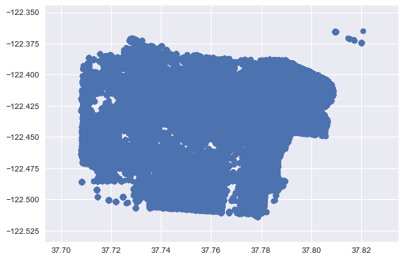

```python
#scatter matrix
###What is our x and what is our y?????
plt.scatter(crime_df['Y'],crime_df['X'])
plt.show()
```

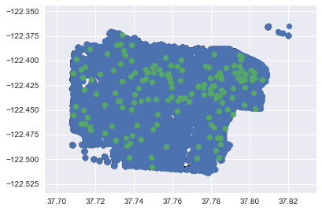

```python
plt.scatter(crime_df['Y'],crime_df['X'])
plt.scatter(coords.T[0],coords.T[1])
plt.show()
```

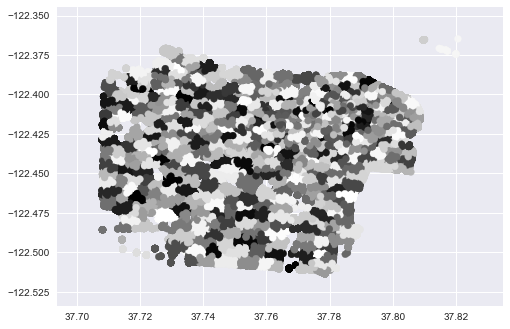

```python
#cluster crime activity?
d1 = crime_df['Y'].values
d2 = crime_df['X'].values

d1w = whiten(d1)
d2w = whiten(d2)

data = np.array([d1w, d2w]).T
km = KMeans(n_clusters=469, random_state=42)
km.fit(data)
plt.scatter(d1,d2, c=km.labels_);
plt.show()
```

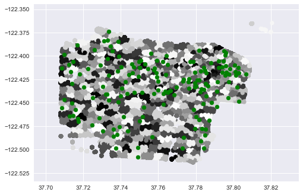

```python
plt.scatter(d1,d2, c=km.labels_);
plt.scatter(coords.T[0],coords.T[1], color="green")

plt.show()
```

We clustered our data in the hopes of condensing to see obvious correlations after mapping the parks scatter matrix on top. However, this did not seem to work. After looking at the amount of data we had, we decided to do a value counts on our locations to see if there was any overlap. Since there was significant amounts of overlap, it occurred to us that we should try a density based mapping for our data. So, we used hexbin plotting again.

```python
crime_loc = crime_df['Location'].value_counts()
#number of unique crime locations
```

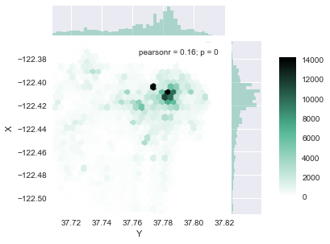

```python
hexplot = sns.jointplot(x=crime_df["Y"], y=crime_df["X"], kind="hex", color="#4CB391", gridsize=30);

#color bar for axes
sns.plt.subplots_adjust(left=0.2, right=0.8, top=0.8, bottom=0.2)  # shrink fig so cbar is visible
cax = hexplot.fig.add_axes([.85, .25, .05, .4])  # x, y, width, height
sns.plt.colorbar(cax=cax)
plt.show()
```

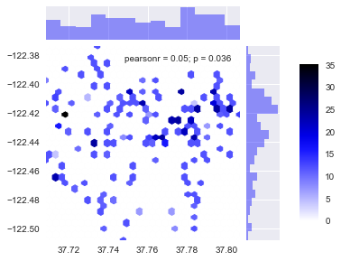

```python
hexplot1 = sns.jointplot(x=coords.T[0], y=coords.T[1], kind="hex", color="blue", gridsize=30);

#color bar for axes
sns.plt.subplots_adjust(left=0.2, right=0.8, top=0.8, bottom=0.2)  # shrink fig so cbar is visible
cax = hexplot1.fig.add_axes([.85, .25, .05, .4])  # x, y, width, height
sns.plt.colorbar(cax=cax)
plt.show()
```

## Data Analysis and More Visualization

We found out it wasn't possible to plot two hexbin plots on top of each other so we tried to compare the park vs the crime hexbins by eye. We didn't see a possible correlation so we decided to look use Nearest Neighbors to analyze our data. This way, we could see the nearest crimes occuring to parks. For this, we looked to find all crimes occuring within 1000 feet of parks.

```python
#get locations of crimes
crime_locations = []
for i in crime_df['Location']:
    crime_locations.append(strToCoord(i))
```

```python
crime_locs = list(crime_df['Location'].value_counts().index)
```

```python
#find distance to nearest park.
def nearest(point,data):
    min_dist = 999999
    for val in data:
        temp = vincenty(point,val).feet
        if temp < min_dist:
            min_dist = temp
    return min_dist

def kNearestNeighbor(point, data, k=1):
    dist_array = []
    for val in data:
        dist_array.append(np.linalg.norm(point-val))
    enum_array = sorted(enumerate(dist_array),key=lambda i:i[1])
    indices = []
    for i in range(k):
        indices.append(enum_array[i][0])
    return indices

#units in feet
def numCrimesInRadius(point,data,rad=50):
    count = 0
    for val in data:
        if vincenty(point,val).feet <= 50:
            count += 1
    return count
```

```python
nearests = []
for idx,coord in enumerate(crime_locs):
    nearests.append(nearest(strToCoord(crime_df['Location'].value_counts().index[idx]),coords))
```

```python
#store location and distance to nearest park.
loc_dict = dict()
for idx,val in enumerate(nearests):
    loc_dict[crime_locs[idx]] = val
```

```python
near_col = []
for cord in list(crime_df['Location']):
    near_col.append(loc_dict[cord])
crime_df['Dist_Nearest_Park'] = pd.Series(np.array(near_col),index=crime_df.index)
```

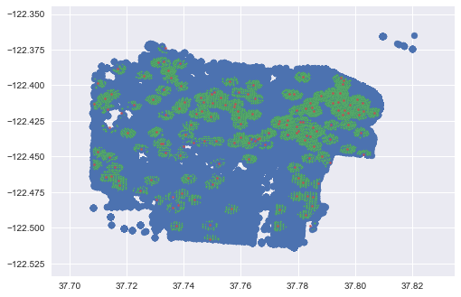

```
219322 within 1000 feet
224461 not within
```

```python
test_dist = 1000
near_park = []
not_near = []
for idx,val in enumerate(crime_locations):
    if near_col[idx] < test_dist:
        near_park.append(val)
    else:
        not_near.append(val)
near_park = np.array(near_park)
not_near = np.array(not_near)

plt.scatter(crime_df['Y'],crime_df['X'])
#plt.scatter(not_near.T[0],not_near.T[1],s=1)
plt.scatter(near_park.T[0],near_park.T[1],s=1)
plt.scatter(coords.T[0],coords.T[1],s=5)

plt.show()

print(len(near_park), "within", test_dist, "feet")
print(len(not_near), "not within")
```

```python
nearest(strToCoord(crime_df['Location'].value_counts().index[0]),coords)
```

```
937.110532567608
```

## Data Analysis and Visualization - Neighborhoods

After plotting the crimes within 1000 feet of a park, we felt like we still didn't see a correlation since the number of crimes occuring within 1000 feet of a park was about equal to the number of crimes not within 1000 feet of a park. So we tried to use the neighborhoods that the police crime dataset was pre-sorted into. We found which parks belonged in which neighborhood and calculated an average park score for each neighborhood. Then, we plotted the number of crimes in each neighborhood against the number of parks to try and find a relationship this way. We also plotted the dataframe as a scatter matrix to look for pairwise correlations

```python
#takes long time to run, just use:
nbrhoods = np.load('Neighborhoods.npy')


# nbrhoods = []
# for row in df_parks.itertuples():
#     coord = strToCoord(row.Location)
#     idx = kNearestNeighbor(np.array(coord),np.array(crime_locations))[0]
#     temp = str(crime_locations[idx])
#     temp = temp[1:len(temp)-1]
#     nbrhd = crime_df[crime_df['Location'] == temp]['PdDistrict'].value_counts().index[0]
#     nbrhoods.append(nbrhd)
```

```python
#create a dataframe of all the parks with their corresponding neighborhoods
df_parks['Neighborhood'] = pd.Series(np.array(nbrhoods), index=df_parks.index)
df_parks
```

|  | Location | Park | ParkID | mean_score_12 | mean_score_13 | mean_score_14 | Neighborhood |
| --- | --- | --- | --- | --- | --- | --- | --- |
| 0 | 37.7400257, -122.44273225 | Glen Park | 1 | 0.891000 | 0.925250 | 0.913000 | INGLESIDE |
| 1 | 37.74058384, -122.43436978 | Walter Haas Playground | 4 | 0.929500 | 0.880500 | 0.932500 | INGLESIDE |
| 2 | 37.74347014, -122.44055037 | George Christopher Playground | 7 | 0.946000 | 0.936750 | 0.953750 | INGLESIDE |
| 3 | 37.74727823, -122.43893283 | Douglass Playground | 8 | 0.945750 | 0.824500 | 0.869500 | MISSION |
| 4 | 37.73060291, -122.48041933 | Rolph Nicol Playground | 9 | 0.924750 | 0.924000 | 0.872000 | TARAVAL |
| 5 | 37.72482337, -122.47385187 | Junipero Serra Playground | 13 | 0.940500 | 0.898333 | 0.964000 | TARAVAL |
| 6 | 37.70860406, -122.4553029 | Lessing-Sears Mini Park | 14 | 0.855250 | 0.911000 | 0.784500 | INGLESIDE |
| 7 | 37.71388814, -122.45029719 | Cayuga Playground | 15 | NaN | NaN | 0.981250 | INGLESIDE |
| 8 | 37.71451213, -122.46369333 | Randolph-Bright Mini Park | 16 | 0.823333 | 0.939750 | 0.894500 | TARAVAL |
| 9 | 37.71750931, -122.47028126 | Merced Heights Playground | 17 | 0.859500 | 0.956000 | 0.922500 | TARAVAL |
| 10 | 37.71727397, -122.46676875 | Brooks Park | 18 | 0.908250 | 0.823750 | 0.918750 | TARAVAL |
| 11 | 37.71577016, -122.45757024 | Minnie & Lovie Ward Recreation Center | 19 | 0.832500 | 0.876250 | 0.876000 | TARAVAL |
| 12 | 37.74243091, -122.42779751 | Upper Noe Recreation Center | 22 | 0.913333 | 0.963750 | 0.935000 | INGLESIDE |
| 13 | 37.74950391, -122.42199245 | Juri Commons | 23 | 0.970000 | 0.924250 | 0.907750 | MISSION |
| 14 | 37.75020058, -122.4122356 | Garfield Square | 24 | 0.871250 | 0.964250 | 0.965250 | MISSION |
| 15 | 37.7098271, -122.44665065 | Alice Chalmers Playground | 25 | 0.903250 | 0.815250 | 0.815250 | INGLESIDE |
| 16 | 37.70854271, -122.41314877 | Kelloch Velasco Mini Park | 26 | 0.952750 | 0.916250 | 0.913000 | INGLESIDE |
| 17 | 37.71240126, -122.40908547 | Visitacion Valley Playground | 27 | 0.865800 | 0.899250 | 0.717500 | INGLESIDE |
| 18 | 37.7180842, -122.41907209 | John McLaren Park | 28 | 0.787875 | 0.819909 | 0.899438 | INGLESIDE |
| 19 | 37.7203554, -122.43321862 | Excelsior Playground | 29 | 0.938500 | 0.843667 | 0.869750 | INGLESIDE |
| 20 | 37.72934205, -122.40978 | Palega Recreation Center | 30 | 0.845667 | NaN | 0.969500 | BAYVIEW |
| 21 | 37.73365828, -122.42064294 | St. Mary's Recreation Center | 31 | 0.944333 | 0.977500 | 0.970250 | INGLESIDE |
| 22 | 37.73844636, -122.41615685 | Bernal Heights Recreation Center | 33 | 0.985750 | 0.939750 | 0.965500 | INGLESIDE |
| 23 | 37.74442266, -122.41966647 | Coleridge Mini Park | 34 | 0.938250 | 1.000000 | 0.962500 | INGLESIDE |
| 24 | 37.74706232, -122.41202466 | Precita Park | 37 | 0.927500 | 0.973750 | 0.944750 | INGLESIDE |
| 25 | 37.72593906, -122.39329436 | Bay View Playground | 38 | 0.882250 | 0.892250 | 0.836750 | BAYVIEW |
| 26 | 37.73285911, -122.40314958 | Silver Terrace Playground | 39 | 0.924250 | 0.911500 | 0.877500 | BAYVIEW |
| 27 | 37.73453491, -122.389412 | Joseph Lee Recreation Center | 40 | 0.938250 | 0.905000 | 0.941500 | BAYVIEW |
| 28 | 37.70996909, -122.39820878 | Little Hollywood Park | 42 | 0.864000 | 0.902000 | 0.833000 | BAYVIEW |
| 29 | 37.71698202, -122.38809021 | Gilman Playground | 44 | 0.924000 | 0.782250 | 0.796500 | BAYVIEW |
| ... | ... | ... | ... | ... | ... | ... | ... |
| 125 | 37.73273279, -122.4408417 | Joost-Baden Mini Park | 158 | 0.961000 | 1.000000 | 0.937500 | INGLESIDE |
| 126 | 37.73033758, -122.43294264 | Cayuga-Lamartine Mini Park | 159 | 0.893250 | 0.946000 | 0.852600 | INGLESIDE |
| 127 | 37.74928062, -122.50817528 | Lower Great Highway | 163 | 0.780000 | 0.814750 | 0.856750 | TARAVAL |
| 128 | 37.7140459, -122.42923866 | Crocker Amazon Playground | 164 | 0.931000 | 0.904000 | 0.861625 | INGLESIDE |
| 129 | 37.79131306, -122.45397275 | Julius Kahn Playground | 166 | 0.937250 | 0.929500 | 0.951750 | RICHMOND |
| 130 | 37.75223367, -122.45453246 | Midtown Terrace Playground | 167 | 0.964250 | 0.961750 | 0.975000 | PARK |
| 131 | 37.78482103, -122.41540228 | Tenderloin Children's Recreation Center | 168 | 0.939000 | 0.978000 | 0.966500 | TENDERLOIN |
| 132 | 37.77700947, -122.40595532 | Victoria Manalo Draves Park | 169 | 0.943500 | 0.959750 | 0.970500 | SOUTHERN |
| 133 | 37.79584858, -122.41033649 | Woh Hei Yuen Park | 170 | 0.956250 | 0.916000 | 0.895500 | CENTRAL |
| 134 | 37.78326998, -122.47797676 | Richmond Recreation Center | 172 | 0.954750 | 0.991750 | 0.992500 | RICHMOND |
| 135 | 37.74607638, -122.40880708 | Mullen-Peralta Mini Park | 176 | 0.936000 | 0.968750 | 0.972250 | INGLESIDE |
| 136 | 37.71476638, -122.40613194 | Visitacion Valley Greenway | 177 | 0.971750 | 0.920750 | 0.920000 | INGLESIDE |
| 137 | 37.73193576, -122.44076127 | Sunnyside Conservatory | 180 | 0.987250 | 0.992750 | 0.978000 | INGLESIDE |
| 138 | 37.78018588, -122.43178038 | Fillmore-Turk Mini Park | 182 | 0.818000 | 0.877667 | 0.921000 | NORTHERN |
| 139 | 37.80289031, -122.4178443 | Fay Park | 184 | 0.993000 | 0.978500 | 0.972000 | CENTRAL |
| 140 | 37.75439053, -122.41356906 | Parque Ninos Unidos | 187 | 0.888250 | 0.935250 | 0.964000 | MISSION |
| 141 | 37.73551382, -122.39472336 | Palou-Phelps Park | 188 | 0.843500 | 0.805500 | 0.886750 | BAYVIEW |
| 142 | 37.76415431, -122.42027989 | Kid Power Park | 191 | 0.983750 | 0.989000 | 0.989000 | MISSION |
| 143 | 37.78274031, -122.41596297 | Turk-Hyde Mini Park | 192 | 0.826500 | 0.960750 | 0.922000 | TENDERLOIN |
| 144 | 37.76578838, -122.43790519 | Peixotto Playground | 195 | 0.980500 | 0.923250 | 0.929500 | PARK |
| 145 | 37.71262222, -122.46422924 | Head-Brotherhood Mini Park | 196 | 0.871000 | 0.975250 | 0.836250 | TARAVAL |
| 146 | 37.74624354, -122.41812033 | Coso-Precita Mini Park | 199 | 0.937500 | 1.000000 | 0.984500 | INGLESIDE |
| 147 | 37.76380044, -122.43785312 | States Street Playground | 200 | 0.878250 | 0.851000 | 0.829750 | PARK |
| 148 | 37.74021712, -122.41187368 | Prentiss Mini Park | 201 | 0.943750 | 0.950333 | 0.984500 | INGLESIDE |
| 149 | 37.76251745, -122.40599759 | Utah-18th Street Mini Park | 202 | 0.869750 | 1.000000 | 0.954750 | MISSION |
| 150 | 37.79643576, -122.41742319 | Broadway Tunnel West Mini Park | 203 | 0.935250 | 0.910750 | 0.935750 | CENTRAL |
| 151 | 37.77622289, -122.42441307 | Patricia's Green in Hayes Valley | 59481 | 0.888000 | 0.983000 | 0.863000 | NORTHERN |
| 152 | 37.76655956, -122.43732268 | Roosevelt-Henry Steps | 107857 | 0.881500 | 0.900000 | 0.913000 | PARK |
| 153 | 37.72245982, -122.41392441 | Louis Sutter Playground | 137665 | 0.868667 | 0.929750 | 0.906000 | BAYVIEW |
| 154 | 37.71348444, -122.41659732 | Herz Playground | 137671 | 0.848000 | 0.876500 | 0.909333 | INGLESIDE |

155 rows × 7 columns

```python
#find the average scores for each park.
df_parks = df_parks.fillna(-1)
means = []
for row in df_parks.itertuples():
    _mean = 0
    _tot = 0
    if row.mean_score_12 != -1:
        _mean += row.mean_score_12
        _tot += 1
    if row.mean_score_13 != -1:
        _mean += row.mean_score_13
        _tot += 1
    if row.mean_score_14 != -1:
        _mean += row.mean_score_14
        _tot += 1
    means.append(_mean/_tot)

means = np.array(means)
df_parks['score'] = pd.Series(means,index=df_parks.index)
```

```python
#create a neighborhood dataframe with number of crimes
df_nbr = pd.DataFrame(crime_df['PdDistrict'].value_counts())
```

```python
#find the average score within each neighborhood and add to neighborhood dataframe
nbrmeans = []
for n in df_nbr.index:
    nbrmeans.append(np.mean(np.array(df_parks[df_parks['Neighborhood'] == n]['score'])))
df_nbr['Avg_Score'] = pd.Series(nbrmeans,index=df_nbr.index)
```

```python
#rename columns of neighborhood datframe to make sense
df_nbr = df_nbr.rename(index=str, columns={"Avg_Score": "Avg_Park_Score"})
df_nbr = df_nbr.rename(index=str, columns={"PdDistrict": "Num_Crimes"})
```

```python
#add number of parks to neighborhood dataframe

numparks = []
for n in df_nbr.index:
    numparks.append(df_parks['Neighborhood'].value_counts()[n])
df_nbr['Num_Parks'] = pd.Series(numparks,index=df_nbr.index)
```

```python
df_nbr
```

|  | Num_Crimes | Avg_Park_Score | Num_Parks |
| --- | --- | --- | --- |
| SOUTHERN | 83993 | 0.922521 | 4 |
| MISSION | 59380 | 0.918019 | 18 |
| NORTHERN | 52864 | 0.927275 | 19 |
| CENTRAL | 46157 | 0.939610 | 18 |
| BAYVIEW | 43170 | 0.891632 | 16 |
| INGLESIDE | 38548 | 0.927106 | 27 |
| TENDERLOIN | 36164 | 0.923750 | 4 |
| TARAVAL | 31751 | 0.903539 | 20 |
| PARK | 27557 | 0.922279 | 12 |
| RICHMOND | 24199 | 0.930766 | 17 |

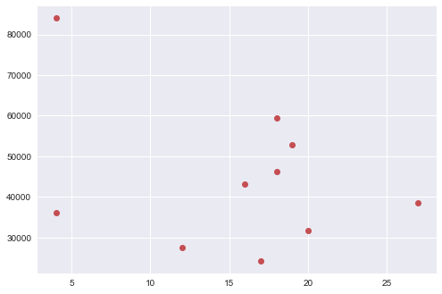

```python
plt.plot(df_nbr['Num_Parks'],df_nbr['Num_Crimes'],'ro')
plt.show()
```

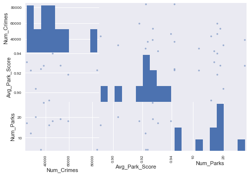

```python
#show a scatter matrix of the columns to look for pairwise correlations
pd.scatter_matrix(df_nbr)
plt.show()
```

## Data Analysis

After all our visualizations, we're pretty confident there is no correlation based on our data. We decide to use OLS and see what the results are.

```python
outcome, predictors = patsy.dmatrices('Num_Crimes ~ Num_Parks + Avg_Park_Score', df_nbr)
mod = sm.OLS(outcome, predictors)
res = mod.fit()
```

```python
print(res.summary())
```

```
                            OLS Regression Results
==============================================================================
Dep. Variable:             Num_Crimes   R-squared:                       0.117
Model:                            OLS   Adj. R-squared:                 -0.136
Method:                 Least Squares   F-statistic:                    0.4619
Date:                Tue, 13 Jun 2017   Prob (F-statistic):              0.648
Time:                        16:40:10   Log-Likelihood:                -110.86
No. Observations:                  10   AIC:                             227.7
Df Residuals:                       7   BIC:                             228.6
Df Model:                           2
Covariance Type:            nonrobust
==================================================================================
                     coef    std err          t      P>|t|      [0.025      0.975]
----------------------------------------------------------------------------------
Intercept        1.41e+04   4.21e+05      0.033      0.974   -9.82e+05    1.01e+06
Num_Parks       -843.9841    883.277     -0.956      0.371   -2932.602    1244.634
Avg_Park_Score  4.709e+04   4.57e+05      0.103      0.921   -1.03e+06    1.13e+06
==============================================================================
Omnibus:                        0.407   Durbin-Watson:                   0.395
Prob(Omnibus):                  0.816   Jarque-Bera (JB):                0.485
Skew:                           0.294   Prob(JB):                        0.785
Kurtosis:                       2.095   Cond. No.                     1.77e+03
==============================================================================

Warnings:
[1] Standard Errors assume that the covariance matrix of the errors is correctly specified.
[2] The condition number is large, 1.77e+03. This might indicate that there are
strong multicollinearity or other numerical problems.
```

## Conclusion

We began our data analysis of crime and park correlations by attempting various different ways to visualize the data. The sheer amount of crimes committed meant that just using a scatter plot did not tell us much. So, we attempted to group our data by using clustering and density based hex plotting. While this helped us see where concentrations of parks compared to concentrations of crimes looked like, we were not able to plot over each other. So, we decided to use the neighborhood police districts to sort all of our data into groups. This left us with a few points we could plot and use in our OLS. The downside of this was that there were not enough data points for us to make any kind of clear visualization judgement.

We have failed to find any correlation between park scores, park locations and criminal activity. Some possible reasonings why could be attributed to the way we decided to analyze the data. The size of our hex binnning as well as the kmeans we used for clustering and the distance we used for nearest neighbor algorithms could have changed our results since different numbers would've changed the number of parks/crimes within a certain area/cluster/hex bin.

For our nearest neighbor algorithm, we assumed that all parks were the same size since we just gave each park a 1000 feet radius to look for crime within. However, knowing what we know about San Francisco, the parks can range from a large acreage such as Golden Gate Park to a smaller neighborhood park. We did not know how to account for this in our visualizations or in our criminal activity calculations.

Our final decision to use the predetermined neighborhoods we were given potentially biased the data as well since the number of parks and crimes could be correlated to a different independent variable we did not look into, such as median income for example.

However, the data we chose to use in this analysis also came with its own biases. Since the park score data is scored by the Recreation and Parks Department of San Francisco, this data is biased by their scoring algorithm. The scoring algorithm may or may not take into account crime rates in the area. If they do, we would have biased data. In addition, there may have been parks or crimes that were not included in the datasets we used which we would have no way of accounting for.

It is also possible that our original hypothesis is incorrect since most data out there on this subject is focused on crime within the parks themselves whereas our hypotheses is related to crime surrounding parks. It is also possible that the correlation between parks and crime is too weak (if at all correlated) to produce a result that is clearly negative or positive.

Based on our OLS, using an alpha value of 0.05, we can say that there is no significant correlation between criminal activity and number of parks/average park score in each neighborhood.